# Task3

### Dimensionality Reduction with Chi2

```
25 feature used in this results.
Results for Training
ROC Score: 0.7396304041167138
Log Loss: 0.5128341583484333
Accuracy: 0.7409860294117647
F1 Score: 0.7571986715482253
========================================
Results for Testing
ROC Score: 0.7374162576562016
Log Loss: 0.515315515272821
Accuracy: 0.7387975
F1 Score: 0.7552157889927816
```

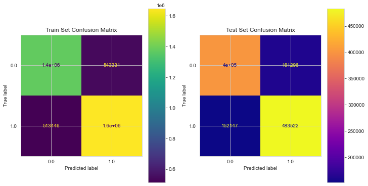

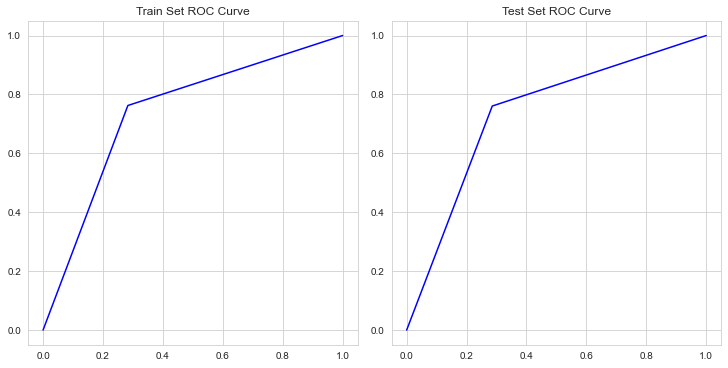

```
20 feature used in this results.
Results for Training
ROC Score: 0.7392975342378064
Log Loss: 0.5133032702676995
Accuracy: 0.7406382352941177
F1 Score: 0.7568109060907815
========================================
Results for Testing
ROC Score: 0.7370880934298643
Log Loss: 0.5157321378746879
Accuracy: 0.7384466666666667
F1 Score: 0.7547948993989091
```

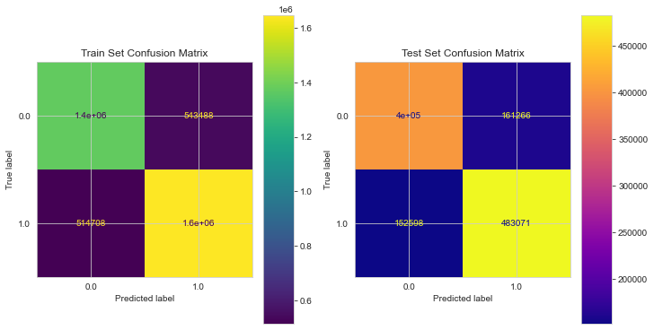

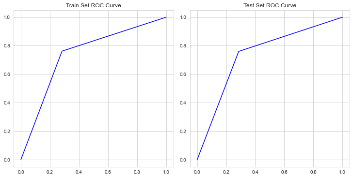

```
15 feature used in this results.
Results for Training
ROC Score: 0.7335302284812628
Log Loss: 0.5233547248875734
Accuracy: 0.7345904411764705
F1 Score: 0.7499536447039161
========================================
Results for Testing
ROC Score: 0.7318929480133655
Log Loss: 0.5255938859428513
Accuracy: 0.7329733333333334
F1 Score: 0.7484874648749628
```

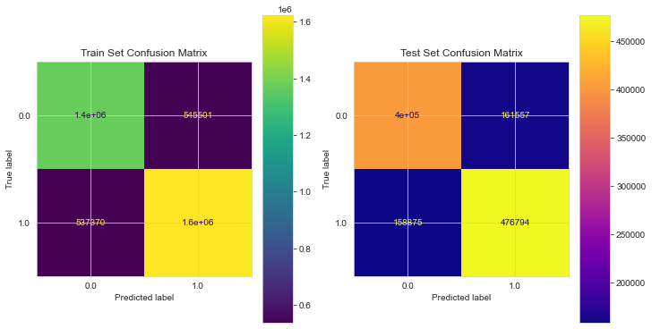

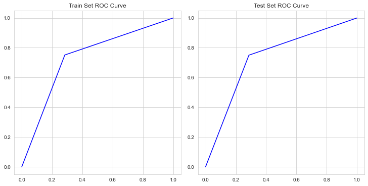

```
10 feature used in this results.
Results for Training
ROC Score: 0.709090578859231
Log Loss: 0.557466673169634
Accuracy: 0.7089306372549019
F1 Score: 0.7199812874895691
========================================
Results for Testing
ROC Score: 0.7073721653102785
Log Loss: 0.5599522071691806
Accuracy: 0.7072525
F1 Score: 0.7185226197410834
```

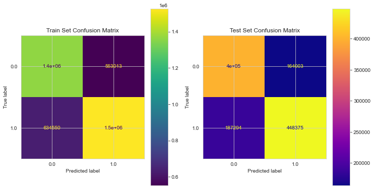

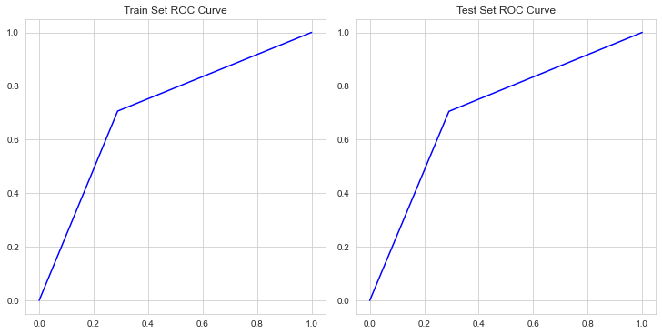

```
5 feature used in this results.
Results for Training
ROC Score: 0.6531112134139229
Log Loss: 0.6178838105963416
Accuracy: 0.6541813725490196
F1 Score: 0.6727767936699215
========================================
Results for Testing
ROC Score: 0.6512763612957955
Log Loss: 0.6198026350797272
Accuracy: 0.6523816666666666
F1 Score: 0.6712238290252307
```

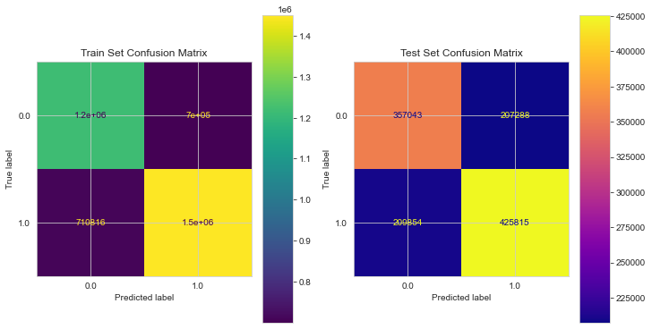

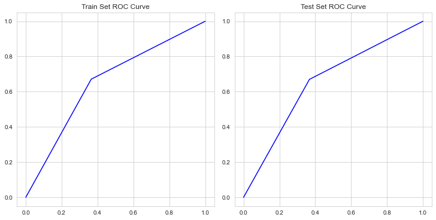

```python
for i in [25, 20, 15, 10, 5]:
    print("{0} feature used in this results.".format(i))
    train_metrics, test_metrics, feature_names = univariate_fs(chi2, i, X_train, X_test,
                                                               y_train, y_test)
    train_reduced_results = store_results(train_reduced_results, train_metrics)
    test_reduced_results = store_results(test_reduced_results, test_metrics)
```

```python
test_reduced_results["Feature_Count"] = test_reduced_results["Feature_Names"].str.len()
train_reduced_results["Feature_Count"] = train_reduced_results["Feature_Names"].str.len()
```

```python
train_reduced_results
```

|  | ROC | LogLoss | Accuracy | F1 | Feature_Names | Feature_Count |
| --- | --- | --- | --- | --- | --- | --- |
| 0 | 0.739630 | 0.512834 | 0.740986 | 0.757199 | [1, 3, 4, 5, 6, 7, 8, 9, 10, 11, 12, 13, 14, 1... | 25 |
| 1 | 0.739298 | 0.513303 | 0.740638 | 0.756811 | [1, 4, 5, 6, 9, 10, 12, 13, 14, 17, 18, 20, 21... | 20 |
| 2 | 0.733530 | 0.523355 | 0.734590 | 0.749954 | [1, 4, 6, 9, 10, 13, 14, 17, 18, 21, 23, 25, 2... | 15 |
| 3 | 0.709091 | 0.557467 | 0.708931 | 0.719981 | [1, 4, 6, 9, 13, 17, 21, 26, 27, 28] | 10 |
| 4 | 0.653111 | 0.617884 | 0.654181 | 0.672777 | [4, 13, 17, 26, 28] | 5 |

```python
test_reduced_results
```

|  | ROC | LogLoss | Accuracy | F1 | Feature_Names | Feature_Count |
| --- | --- | --- | --- | --- | --- | --- |
| 0 | 0.737416 | 0.515316 | 0.738797 | 0.755216 | [1, 3, 4, 5, 6, 7, 8, 9, 10, 11, 12, 13, 14, 1... | 25 |
| 1 | 0.737088 | 0.515732 | 0.738447 | 0.754795 | [1, 4, 5, 6, 9, 10, 12, 13, 14, 17, 18, 20, 21... | 20 |
| 2 | 0.731893 | 0.525594 | 0.732973 | 0.748487 | [1, 4, 6, 9, 10, 13, 14, 17, 18, 21, 23, 25, 2... | 15 |
| 3 | 0.707372 | 0.559952 | 0.707252 | 0.718523 | [1, 4, 6, 9, 13, 17, 21, 26, 27, 28] | 10 |
| 4 | 0.651276 | 0.619803 | 0.652382 | 0.671224 | [4, 13, 17, 26, 28] | 5 |

So here is the deal. If we look closer to test results we can see 15 feature has % 73.29 accuracy and 10 features has % 70.7 accuracy. If we really really want same accuracy with full features which is %74.0 in test we should chose 15 feature model. But if we can say "OK % 3.5 will not cause problems." then we can pick 10 feature model.

**If we are going to pick 10 featuure model, we will drop 18 feature. Now its % 64 reduced in dimensionality. There is %3.5 accuracy loss.**

### What we could tried ?

- We could try other univariate methods like f_classif and mutual_info_classif. Probably those functions will work as fast as chi2.
- We could try Recursive Feature Elimination known as RFE. This function works recursively and eliminates features that you've selected in every step. It fits data in every step. This method will take some time.
- We could also try Wrapper Methods. Wrapper methods actually uses another machine learning or deep learning model for selectingn features. You can easily observe RandomForestClassifier().feature_importances attribute after fitting process finished. With that option you can pick most k important features and use them in your final model. This can take time too.